# A1

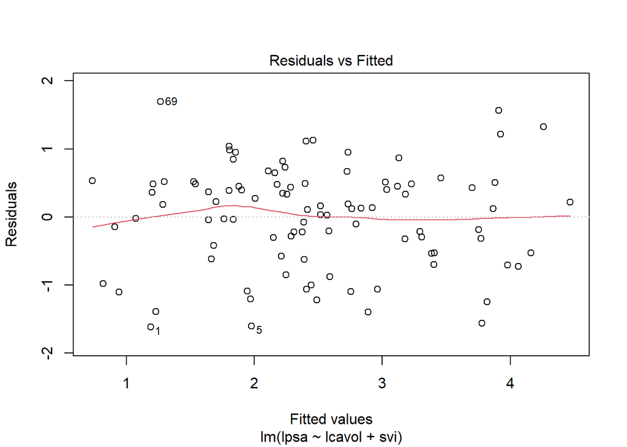

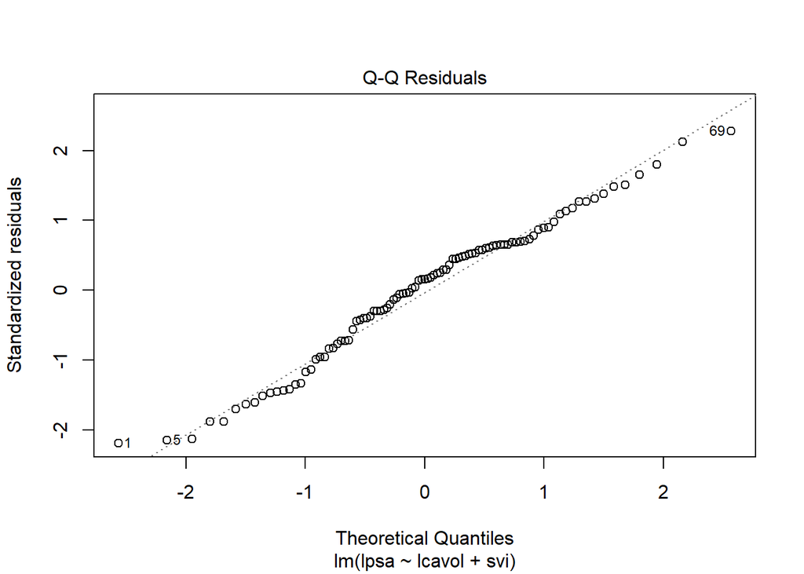

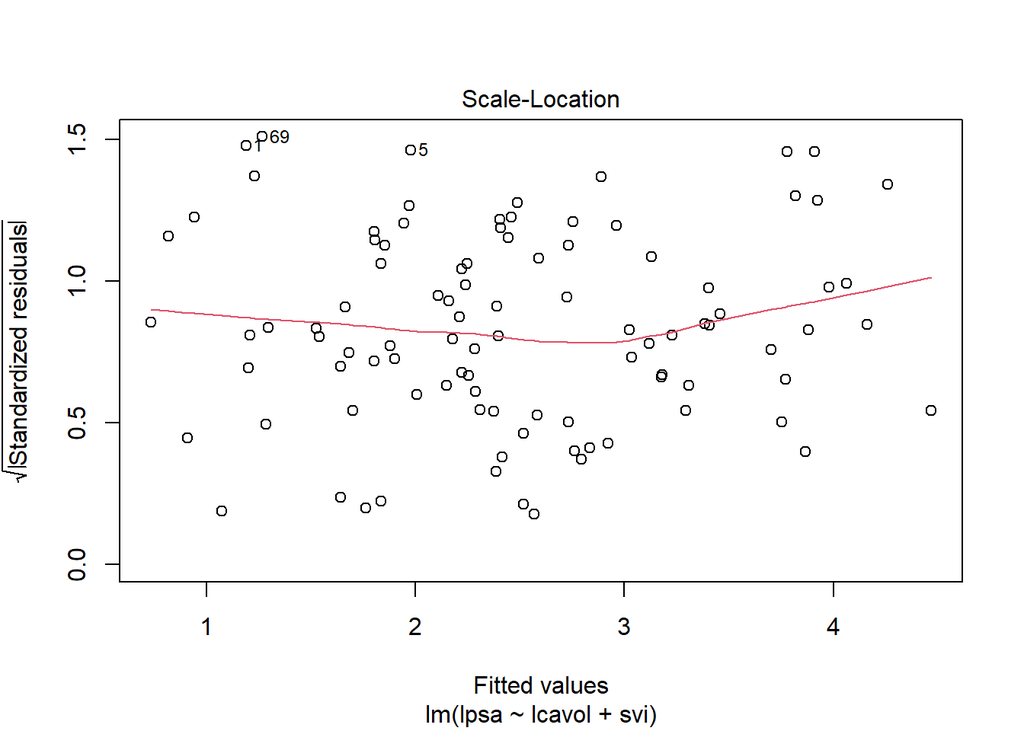

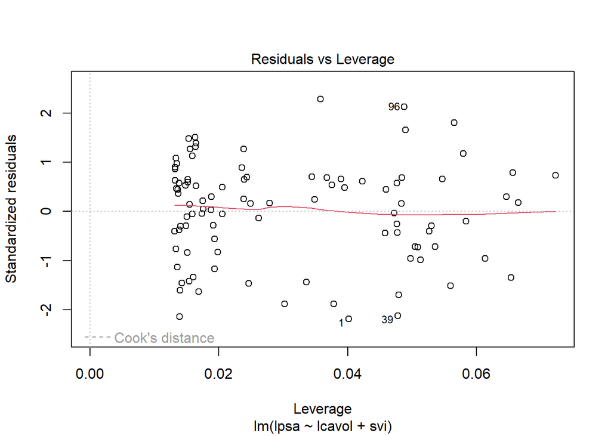

```r
plot(mod_1)
```

**Interpretación:**

**El antígeno prostático se asocia con un aumento del volumen del cancer 0.59.** **La invasión vesicular se asocia con un aumento promedio de 0.67 del factor.**

Obteniendo los residuos del modelo

```r
residuos <- residuals(mod_1)
```

Calculando la media y mediana de los residuos

```r
media_residuos <- mean(residuos)
mediana_residuos <- median(residuos)
print(paste("La media de los residuos es:", media_residuos))
```

```
## [1] "La media de los residuos es: 1.43293524239837e-18"
```

```r
print(paste("La mediana de los residuos es:", mediana_residuos))
```

```
## [1] "La mediana de los residuos es: 0.120094632846938"
```

Calculando el error cuadrático medio (ECM)

```r
ecm <- mean(residuos^2)
print(paste("El error cuadrático medio es:", ecm))
```

```
## [1] "El error cuadrático medio es: 0.553373934295546"
```

Calculando la correlación

```r
cor(residuos, fitted(mod_1))
```

```
## [1] 3.973971e-16
```

Gráfico de dispersión de residuos vs. valores ajustados

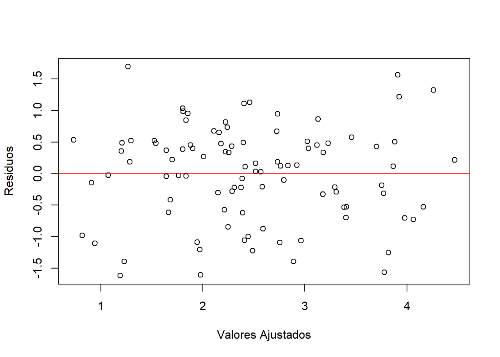

```r
plot(fitted(mod_1), residuos, xlab = "Valores Ajustados", ylab = "Residuos")
abline(h = 0, col = "red")  # Línea horizontal en y=0
```

## Ejercicios del libro de Carmona

#2. (∗∗) (Ejercicio 1.2 del Capítulo 1 página 24)

Tenemos un modelo de regresión lineal simple dado por: y_i = β₀ + β₁x_i + ε_i Donde:

y_i: Valor observado de la variable dependiente en la observación i x_i: Valor observado de la variable independiente en la observación i β₀: Intercepto de la recta de regresión β₁: Pendiente de la recta de regresión ε_i: Error aleatorio

**Crear datos de ejemplo**

```r
set.seed(123)
x <- seq(1, 10, by = 0.5)
y <- 2 + 3*x - 0.5*x^2 + rnorm(length(x), 0, 2)
```

**Crear matriz de diseño**

```r
X <- cbind(1, x, x^2)
```

**Estimar los parámetros**

```r
beta_hat <- solve(t(X) %*% X) %*% t(X) %*% y
```

**Obtener las predicciones**

```r
y_hat <- X %*% beta_hat
```

**Calcular los residuos**

```r
residuals <- y - y_hat
```

**Mostrar los resultados**

```r
print("Estimaciones de los parámetros:")
```

```
## [1] "Estimaciones de los parámetros:"
```

```r
print(beta_hat)
```

```
##         [,1]
##    2.0197184
## x  3.2113898
##   -0.5221044
```

```r
print("Predicciones:")
```

```
## [1] "Predicciones:"
```

```r
print(y_hat)
```

```
##              [,1]
##  [1,]   4.7090039
##  [2,]   5.6620683
##  [3,]   6.3540806
##  [4,]   6.7850407
##  [5,]   6.9549487
##  [6,]   6.8638044
##  [7,]   6.5116080
##  [8,]   5.8983594
##  [9,]   5.0240586
## [10,]   3.8887056
## [11,]   2.4923004
## [12,]   0.8348431
## [13,]  -1.0836664
## [14,]  -3.2632281
## [15,]  -5.7038420
## [16,]  -8.4055080
## [17,] -11.3682263
## [18,] -14.5919967
## [19,] -18.0768193
```

```r
print("Residuos:")
```

```
## [1] "Residuos:"
```

```r
print(residuals)
```

```
##             [,1]
##  [1,] -1.3299552
##  [2,] -0.7474233
##  [3,]  2.7633360
##  [4,] -0.2690239
##  [5,] -0.1963732
##  [6,]  2.9413256
##  [7,]  0.4102244
##  [8,] -3.0534818
##  [9,] -1.8977643
## [10,] -1.4050295
## [11,]  1.9558632
## [12,]  0.2597845
## [13,]  0.3852093
## [14,] -0.1404065
## [15,] -1.4078403
## [16,]  3.3543343
## [17,]  0.8639272
## [18,] -3.9662376
## [19,]  1.4795311
```

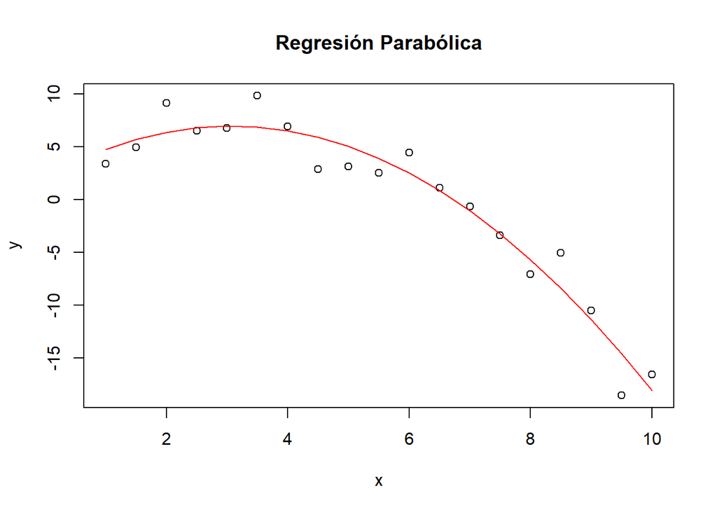

```r
plot(x, y, main = "Regresión Parabólica", xlab = "x", ylab = "y")
lines(x, y_hat, col = "red")
```

**Modelo de regresión lineal (pero con términos cuadráticos)**

```r
modelo <- lm(y ~ x + I(x^2))
```

**Resumen del modelo**

```r
summary(modelo)
```

```
##
## Call:
## lm(formula = y ~ x + I(x^2))
##
## Residuals:
##     Min      1Q  Median      3Q     Max
## -3.9662 -1.3675 -0.1404  1.1717  3.3543
##
## Coefficients:
##             Estimate Std. Error t value Pr(>|t|)
## (Intercept)  2.01972    1.95350   1.034  0.31656
## x            3.21139    0.80793   3.975  0.00109 **
## I(x^2)      -0.52210    0.07171  -7.281 1.84e-06 ***
## ---
## Signif. codes:  0 '***' 0.001 '**' 0.01 '*' 0.05 '.' 0.1 ' ' 1
##
## Residual standard error: 2.088 on 16 degrees of freedom
## Multiple R-squared:  0.9426, Adjusted R-squared:  0.9354
## F-statistic: 131.3 on 2 and 16 DF,  p-value: 1.186e-10
```

**Predicciones**

```r
predicciones <- predict(modelo)

predicciones
```

```
##           1           2           3           4           5           6
##   4.7090039   5.6620683   6.3540806   6.7850407   6.9549487   6.8638044
##           7           8           9          10          11          12
##   6.5116080   5.8983594   5.0240586   3.8887056   2.4923004   0.8348431
##          13          14          15          16          17          18
##  -1.0836664  -3.2632281  -5.7038420  -8.4055080 -11.3682263 -14.5919967
##          19
## -18.0768193
```

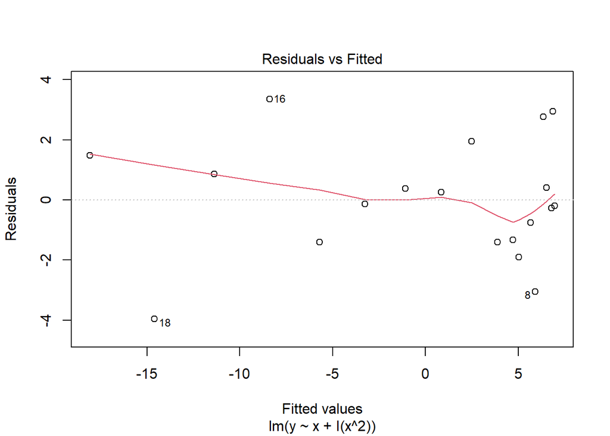

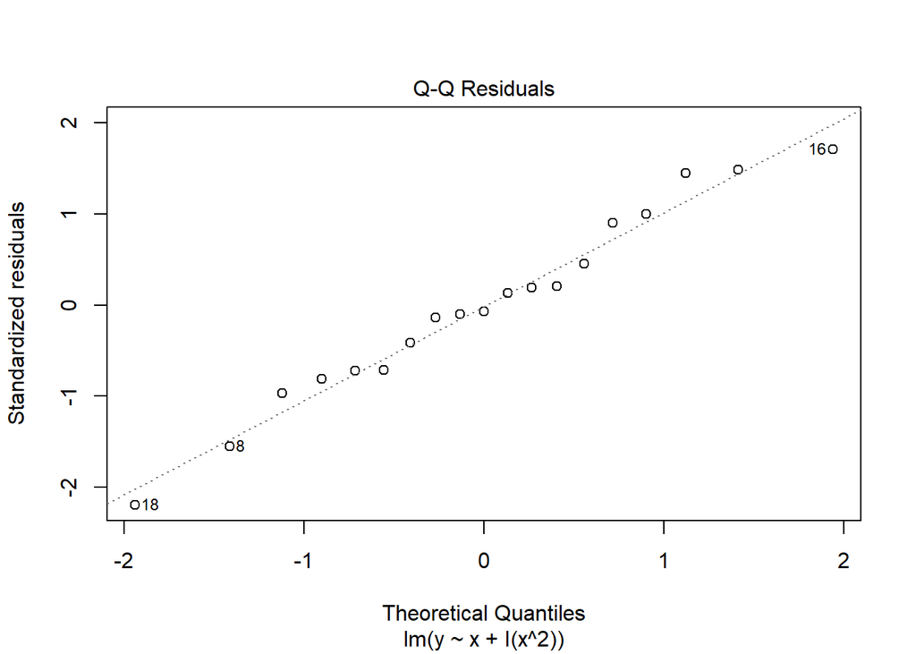

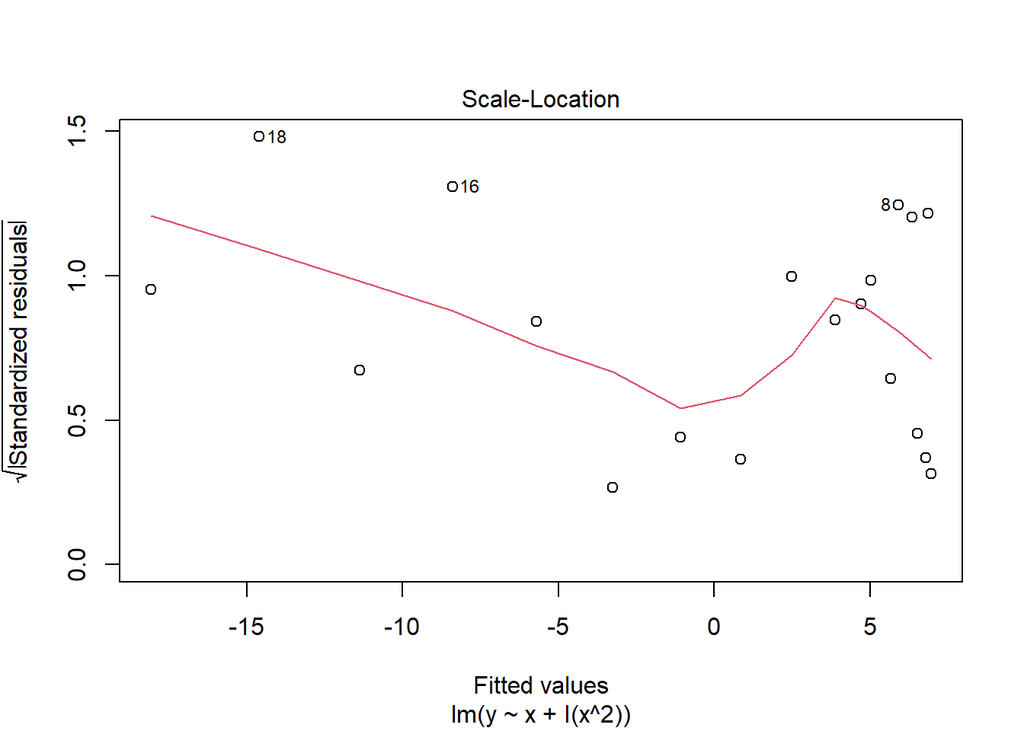

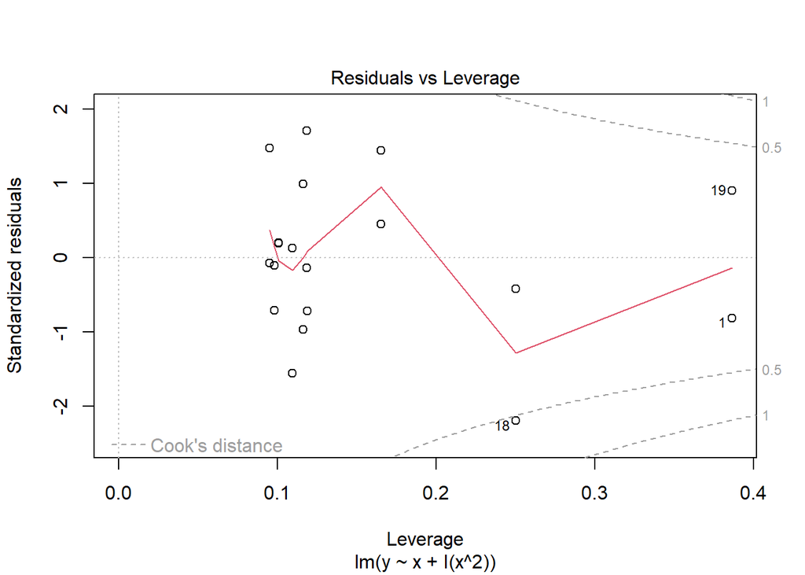

```r
plot(modelo)
```

#3. (Ejercicio 1.3 del Capítulo 1 página 24) Consideremos el problema de tráfico planteado en el apartado 1.2 de este capítulo, con la variable independiente densidad y la variable dependiente raíz cuadrada de la velocidad. Con los datos proporcionados en la tabla 1.1

```r
dens <- c(12.7,17.0,66.0,50.0,87.8,81.4,75.6,66.2,81.1,62.8,77.0,89.6,
          18.3,19.1,16.5,22.2,18.6,66.0,60.3,56.0,66.3,61.7,66.6,67.8)
vel <- c(62.4,50.7,17.1,25.9,12.4,13.4,13.7,17.9,13.8,17.9,15.8,12.6,
         51.2,50.8,54.7,46.5,46.3,16.9,19.8,21.2,18.3,18.0,16.6,18.3)
rvel <- sqrt(vel)
rvel
```

```
##  [1] 7.899367 7.120393 4.135215 5.089204 3.521363 3.660601 3.701351 4.230839
##  [9] 3.714835 4.230839 3.974921 3.549648 7.155418 7.127412 7.395945 6.819091
## [17] 6.804410 4.110961 4.449719 4.604346 4.277850 4.242641 4.074310 4.277850
```

**realizar el siguiente proceso:**

**Crear un data frame con los datos**

```r
set.seed(9512)
datos <- data.frame(densidad = dens, velocidad = vel, raiz_velocidad = rvel)
```

#library(ggplot2)

**Crear un nuevo data frame para los dos puntos**

```r
puntos_linea <- data.frame(x1 =12.7, x2 = 87.8, y1 = 7.899367, y2 = 3.521363)
puntos_linea
```

```
##     x1   x2       y1       y2
## 1 12.7 87.8 7.899367 3.521363
```

**Gráfico**

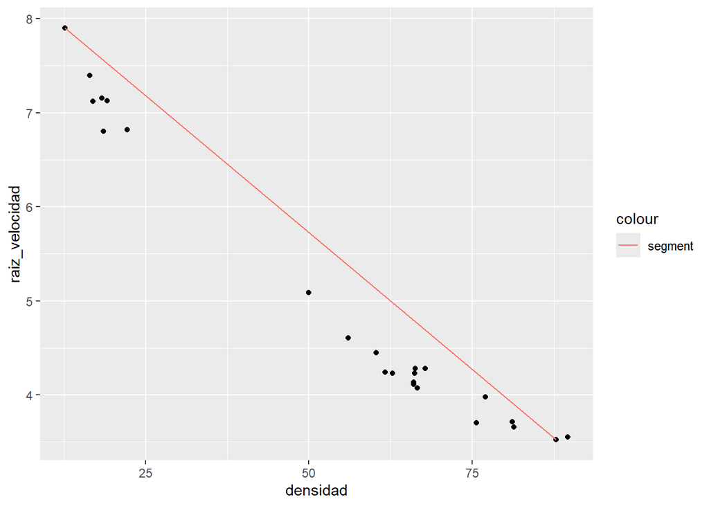

```r
b <- ggplot(datos, aes(x = densidad, y = raiz_velocidad)) +
  geom_point()
b +
  geom_segment(aes(x = x1, y = y1, xend = x2, yend = y2, colour = "segment"), data = puntos_linea)
```

**(b) Hallar la recta de regresión simple. Dibujar el gráfico de los residuos con la densidad y el** **gráfico con las predicciones. Calcular la suma de cuadrados de los residuos.**

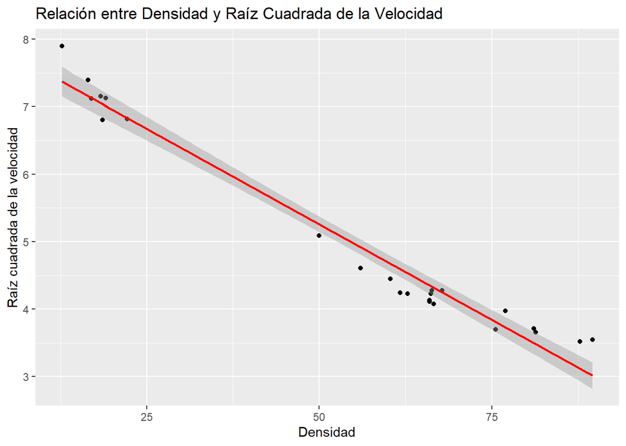

```r
ggplot(datos, aes(x = densidad, y = raiz_velocidad)) +
  geom_point() +
  geom_smooth(method = "lm", color = "red") +
  labs(x = "Densidad", y = "Raíz cuadrada de la velocidad",
       title = "Relación entre Densidad y Raíz Cuadrada de la Velocidad")
```

**Datos (asumiendo que ya los tienes cargados en variables ‘dens’ y ‘vel’)**

```r
datos <- data.frame(densidad = dens, velocidad = vel, raiz_velocidad = rvel)
```

**Ajustar el modelo de regresión lineal**

```r
modelo <- lm(raiz_velocidad ~ densidad, data = datos)
summary(modelo)
```

```
##
## Call:
## lm(formula = raiz_velocidad ~ densidad, data = datos)
##
## Residuals:
##      Min       1Q   Median       3Q      Max
## -0.35337 -0.22722 -0.03566  0.18942  0.53349
##
## Coefficients:
##              Estimate Std. Error t value Pr(>|t|)
## (Intercept)  8.089813   0.130629   61.93   <2e-16 ***
## densidad    -0.056626   0.002177  -26.01   <2e-16 ***
## ---
## Signif. codes:  0 '***' 0.001 '**' 0.01 '*' 0.05 '.' 0.1 ' ' 1
##
## Residual standard error: 0.2689 on 22 degrees of freedom
## Multiple R-squared:  0.9685, Adjusted R-squared:  0.9671
## F-statistic: 676.4 on 1 and 22 DF,  p-value: < 2.2e-16
```

**Obtener los coeficientes del modelo**

```r
coeficientes <- coef(modelo)
coeficientes
```

```
## (Intercept)    densidad
##  8.08981299 -0.05662558
```

**Obtener los residuos**

```r
residuos <- residuals(modelo)
residuos
```

```
##            1            2            3            4            5            6
##  0.528698941 -0.006784881 -0.217310086 -0.169329731  0.403276303  0.180110263
##            7            8            9           10           11           12
## -0.107568040 -0.110360435  0.217356669 -0.302887407  0.245278050  0.533486845
##           13           14           15           16           17           18
##  0.101852653  0.119147462  0.240453916 -0.013634264 -0.232166866 -0.241563754
##           19           20           21           22           23           24
## -0.225571425 -0.314434738 -0.057687111 -0.353374018 -0.244239606  0.027251259
```

**Gráfico de residuos vs. densidad**

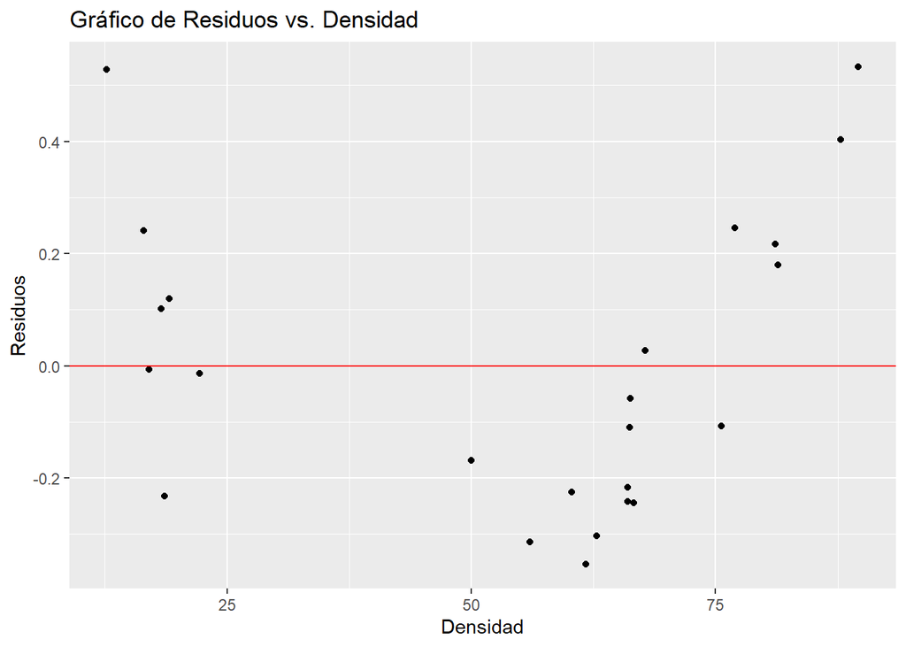

```r
ggplot(data = data.frame(densidad = datos$densidad, residuos),
       aes(x = densidad, y = residuos)) +
  geom_point() +
  geom_hline(yintercept = 0, color = "red") +
  labs(x = "Densidad", y = "Residuos",
       title = "Gráfico de Residuos vs. Densidad")
```

**Gráfico de valores ajustados vs. densidad**

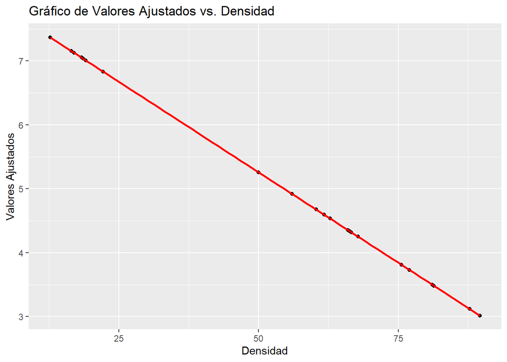

```r
ggplot(data = data.frame(densidad = datos$densidad, ajustados = fitted(modelo)),
       aes(x = densidad, y = ajustados)) +
  geom_point() +
  geom_smooth(method = "lm", se = FALSE, color = "red") +
  labs(x = "Densidad", y = "Valores Ajustados",
       title = "Gráfico de Valores Ajustados vs. Densidad")
```

**Suma de cuadrados de los residuos**

```r
suma_cuadrados_residuos <- sum(residuos^2)
print(suma_cuadrados_residuos)
```

```
## [1] 1.591218
```

#(c) Mejorar el modelo anterior considerando una regresión parabólica. Dibujar el gráfico de los #residuos con la densidad y el gráfico con las predicciones. Calcular la suma de cuadrados de #los residuos.

**Ajustar el modelo de regresión parabólica**

```r
modelo_parabolico <- lm(raiz_velocidad ~ densidad + I(densidad^2), data = datos)
```

**Obtener los residuos**

```r
residuos_parabolicos <- residuals(modelo_parabolico)
```

**Graficar los datos y la curva de regresión**

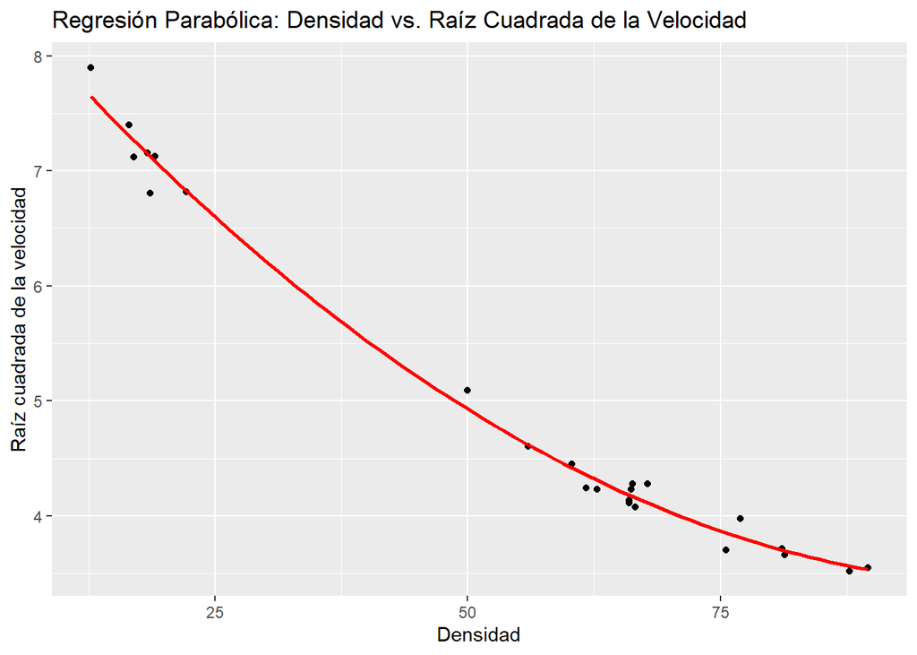

```r
ggplot(datos, aes(x = densidad, y = raiz_velocidad)) +
  geom_point() +
  geom_smooth(method = "lm", formula = y ~ x + I(x^2), se = FALSE, color = "red") +
  labs(x = "Densidad", y = "Raíz cuadrada de la velocidad",
       title = "Regresión Parabólica: Densidad vs. Raíz Cuadrada de la Velocidad")
```

**Gráfico de residuos vs. densidad (modelo parabólico)**

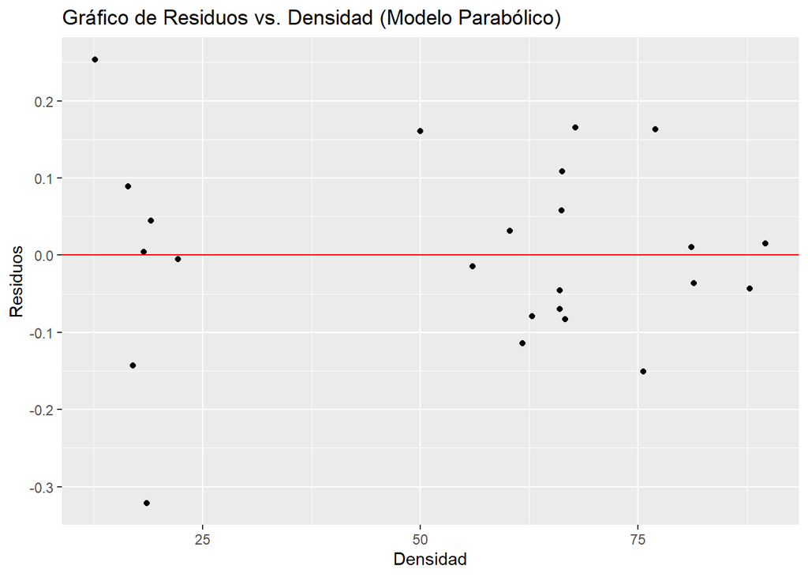

```r
ggplot(data = data.frame(densidad = datos$densidad, residuos = residuos_parabolicos),
       aes(x = densidad, y = residuos)) +
  geom_point() +
  geom_hline(yintercept = 0, color = "red") +
  labs(x = "Densidad", y = "Residuos",
       title = "Gráfico de Residuos vs. Densidad (Modelo Parabólico)")
```

**Gráfico de valores ajustados vs. densidad (modelo parabólico)**

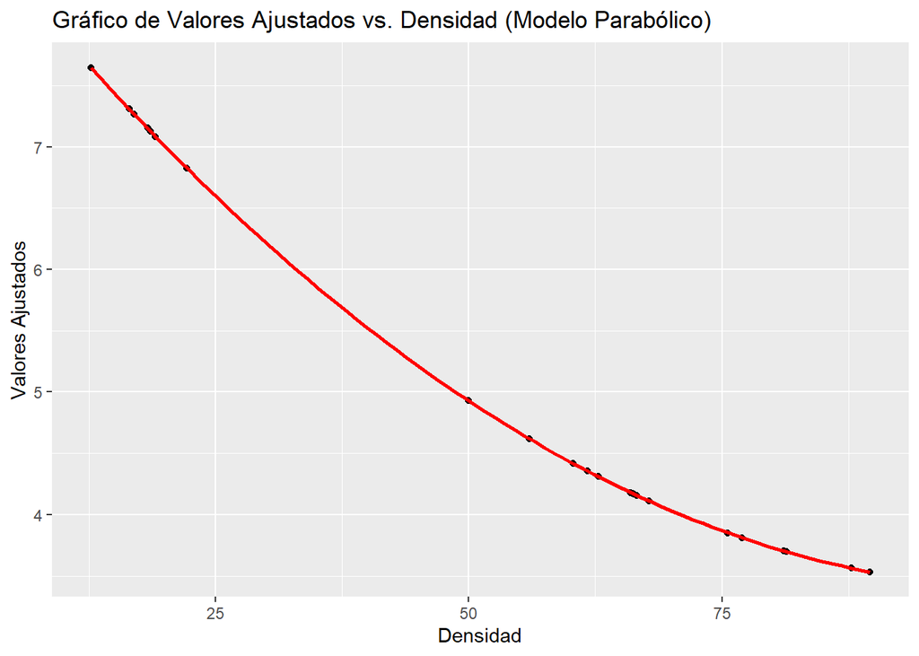

```r
ggplot(data = data.frame(densidad = datos$densidad, ajustados = fitted(modelo_parabolico)),
       aes(x = densidad, y = ajustados)) +
  geom_point() +
  geom_smooth(method = "lm", formula = y ~ x + I(x^2), se = FALSE, color = "red") +
  labs(x = "Densidad", y = "Valores Ajustados",
       title = "Gráfico de Valores Ajustados vs. Densidad (Modelo Parabólico)")
```

**Suma de cuadrados de los residuos (modelo parabólico)**

```r
suma_cuadrados_residuos_parabolico <- sum(residuos_parabolicos^2)
print(suma_cuadrados_residuos_parabolico)
```

```
## [1] 0.3534143
```

#(d) Calcular la capacidad de la carretera o punto de máximo flujo. Recordar que flujo = vel × #densidad.

**La capacidad de una carretera, o punto de máximo flujo, es el valor máximo que puede alcanzar** **el producto de la velocidad y la densidad. En otras palabras, es el punto en el que la carretera** **está más congestionada pero aún permite el mayor flujo vehicular.**

**Crear una nueva columna para el flujo**

Calculamos el flujo multiplicando la densidad por la velocidad y lo agregamos como una nueva columna en nuestro DataFrame.

```r
datos$flujo <- datos$densidad * datos$velocidad
```

Graficar densidad vs. flujo

Creamos un gráfico de dispersión de la densidad vs. el flujo para identificar visualmente dónde se encuentra el máximo.

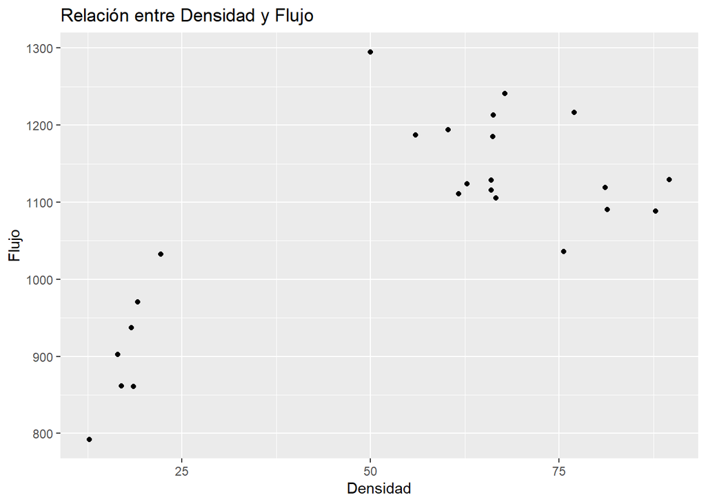

```r
ggplot(datos, aes(x = densidad, y = flujo)) +
  geom_point() +
  labs(x = "Densidad", y = "Flujo", title = "Relación entre Densidad y Flujo")
```

```r
optimizar_flujo <- function(densidad) {
  - (densidad * datos$velocidad[which.min(abs(datos$densidad - densidad))])
}

resultado_optimizacion <- optimize(optimizar_flujo, interval = c(min(datos$densidad), max(datos$densidad)), maximum = TRUE)
```

```r
densidad_max_flujo <- resultado_optimizacion$maximum
```

El flujo máximo es:

```r
flujo_maximo <- max(datos$densidad * datos$velocidad)
```

Imprimir los resultados

```r
cat("La densidad en el punto de máximo flujo es:", densidad_max_flujo, "\n")
```

```
## La densidad en el punto de máximo flujo es: 36.10002
```

```r
cat("El flujo máximo es:", flujo_maximo)
```

```
## El flujo máximo es: 1295
```

### 4. (Ejercicio 1.4 del Capítulo 1 página 24)

Si tomamos como variable regresora o independiente la distancia (metros) y como variable respuesta o dependiente el tiempo (segundos):

**(a) Calcular la recta de regresión simple con los datos de los hombres y dibujarla. Dibujar el gráfico de los residuos con la distancia y el gráfico con las predicciones. Calcular la suma de cuadrados de los residuos y el R2.**

Crear un data frame con los datos

```r
datos <- data.frame(
  distancia = c(100, 200, 400, 800, 1500, 5000, 10000, 42192),
  tiempo_hombres = c(9.84, 19.32, 43.19, 102.58, 215.78, 787.96, 1627.34, 7956.00),
  tiempo_mujeres = c(10.94, 22.12, 48.25, 117.73, 240.83, 899.88, 1861.63, 8765.00)
)

modelo_hombres <- lm(tiempo_hombres ~ distancia, data = datos)
```

Resumen del modelo

```r
summary(modelo_hombres)
```

```
##
## Call:
## lm(formula = tiempo_hombres ~ distancia, data = datos)
##
## Residuals:
##     Min      1Q  Median      3Q     Max
## -186.35  -12.27   37.60   53.79   69.16
##
## Coefficients:
##               Estimate Std. Error t value Pr(>|t|)
## (Intercept) -78.234245  38.827257  -2.015   0.0905 .
## distancia     0.189193   0.002514  75.256 3.71e-10 ***
## ---
## Signif. codes:  0 '***' 0.001 '**' 0.01 '*' 0.05 '.' 0.1 ' ' 1
##
## Residual standard error: 95.91 on 6 degrees of freedom
## Multiple R-squared:  0.9989, Adjusted R-squared:  0.9988
## F-statistic:  5663 on 1 and 6 DF,  p-value: 3.705e-10
```

```r
#library(ggplot2)
```

Gráfico de la dispersión y recta de la regresión

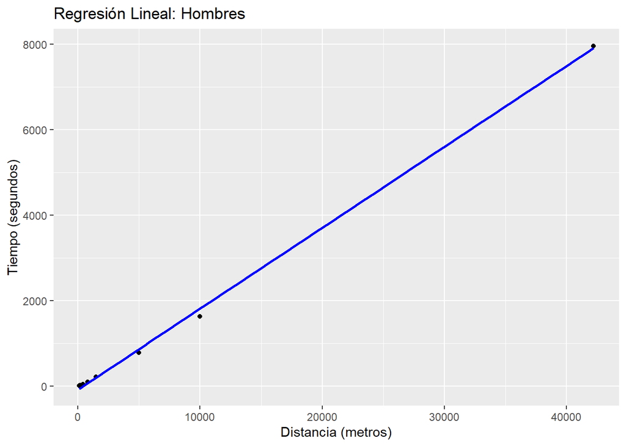

```r
ggplot(datos, aes(x = distancia, y = tiempo_hombres)) +
  geom_point() +
  geom_smooth(method = "lm", se = FALSE, color = "blue") +
  labs(x = "Distancia (metros)", y = "Tiempo (segundos)",
       title = "Regresión Lineal: Hombres")
```

Obtener los residuos

```r
residuos_hombres <- residuals(modelo_hombres)
```

Gráfico de residuos

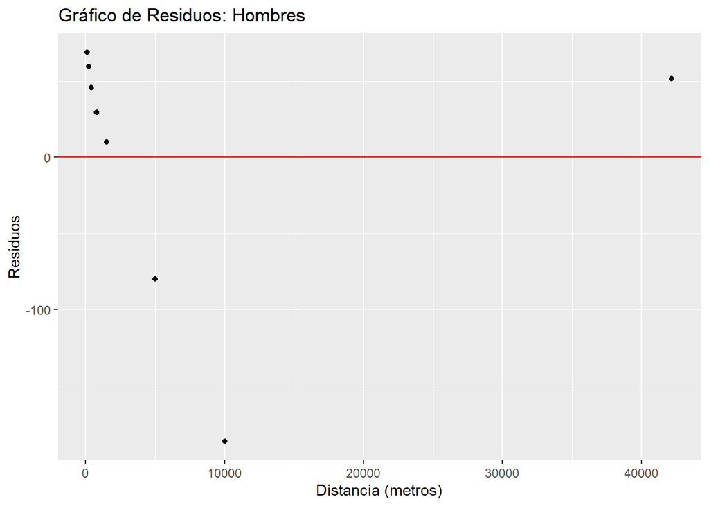

```r
ggplot(data = data.frame(distancia = datos$distancia, residuos = residuos_hombres),
       aes(x = distancia, y = residuos)) +
  geom_point() +
  geom_hline(yintercept = 0, color = "red") +
  labs(x = "Distancia (metros)", y = "Residuos",
       title = "Gráfico de Residuos: Hombres")
```

Gráfico de valores ajustados vs. observados

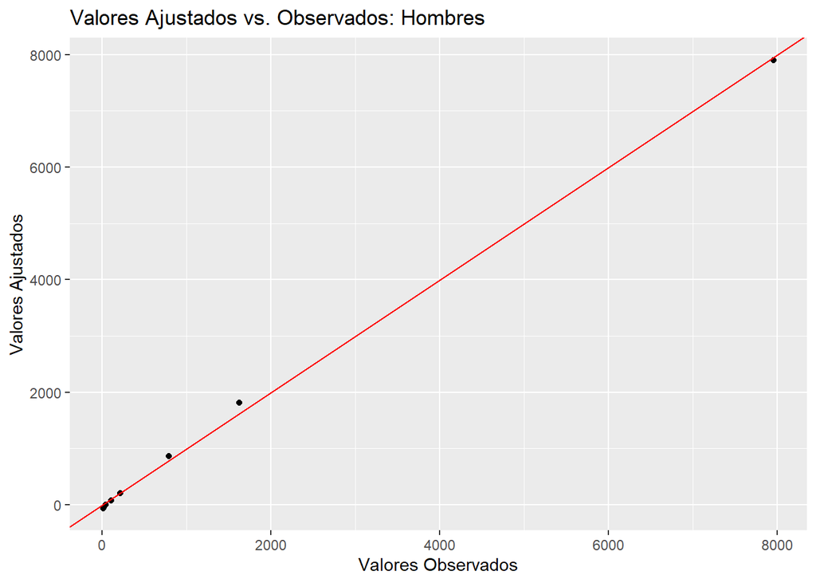

```r
ggplot(data = data.frame(observados = datos$tiempo_hombres, ajustados = fitted(modelo_hombres)),
       aes(x = observados, y = ajustados)) +
  geom_point() +
  geom_abline(intercept = 0, slope = 1, color = "red") +
  labs(x = "Valores Observados", y = "Valores Ajustados",
       title = "Valores Ajustados vs. Observados: Hombres")
```

Cálculo de la suma de cuadrados de los residuos y R²

Suma de cuadrados de los residuos

```r
suma_cuadrados_residuos <- sum(residuos_hombres^2)
print(suma_cuadrados_residuos)
```

```
## [1] 55189
```

R-cuadrado

```r
r_cuadrado <- summary(modelo_hombres)$r.squared
print(r_cuadrado)
```

```
## [1] 0.9989417
```

**(b) Repetir el apartado anterior utilizando los logaritmos de las variables tiempo y distancia.**

Transformar las variables a escala logarítmica

```r
datos$log_distancia <- log(datos$distancia)
datos$log_tiempo_hombres <- log(datos$tiempo_hombres)
```

Regresión lineal con las variables transformadas

```r
modelo_log_hombres <- lm(log_tiempo_hombres ~ log_distancia, data = datos)
```

Resumen del modelo

```r
summary(modelo_log_hombres)
```

```
##
## Call:
## lm(formula = log_tiempo_hombres ~ log_distancia, data = datos)
##
## Residuals:
##       Min        1Q    Median        3Q       Max
## -0.076910 -0.041887  0.003026  0.034941  0.083359
##
## Coefficients:
##               Estimate Std. Error t value Pr(>|t|)
## (Intercept)   -2.88596    0.08066  -35.78 3.18e-08 ***
## log_distancia  1.11809    0.01071  104.44 5.19e-11 ***
## ---
## Signif. codes:  0 '***' 0.001 '**' 0.01 '*' 0.05 '.' 0.1 ' ' 1
##
## Residual standard error: 0.05835 on 6 degrees of freedom
## Multiple R-squared:  0.9995, Adjusted R-squared:  0.9994
## F-statistic: 1.091e+04 on 1 and 6 DF,  p-value: 5.192e-11
```

Gráfico de dispersión y recta de regresión con las variables transformadas

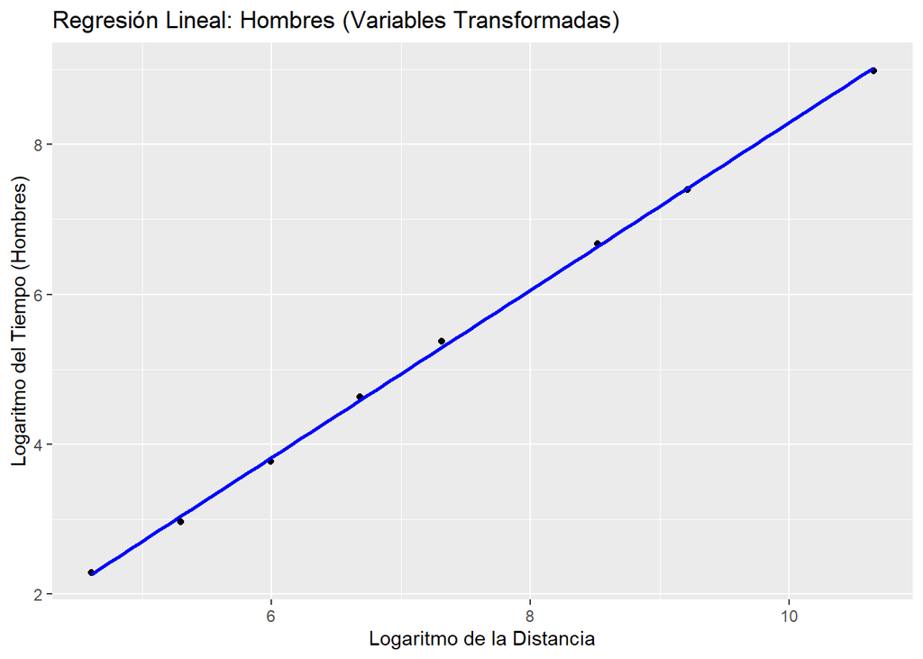

```r
ggplot(datos, aes(x = log_distancia, y = log_tiempo_hombres)) +
  geom_point() +
  geom_smooth(method = "lm", se = FALSE, color = "blue") +
  labs(x = "Logaritmo de la Distancia", y = "Logaritmo del Tiempo (Hombres)",
       title = "Regresión Lineal: Hombres (Variables Transformadas)")
```

Gráfico de residuos vs. logaritmo de la distancia

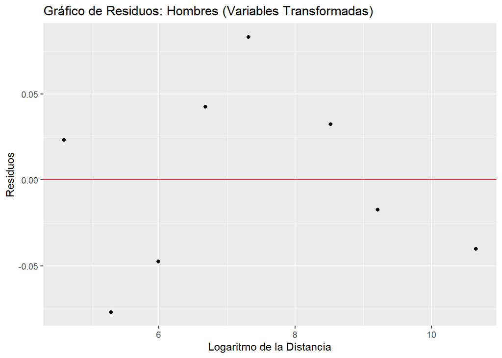

```r
residuos_log_hombres <- residuals(modelo_log_hombres)

ggplot(data = data.frame(log_distancia = datos$log_distancia, residuos = residuos_log_hombres),
       aes(x = log_distancia, y = residuos)) +
  geom_point() +
  geom_hline(yintercept = 0, color = "red") +
  labs(x = "Logaritmo de la Distancia", y = "Residuos",
       title = "Gráfico de Residuos: Hombres (Variables Transformadas)")
```

Gráfico de valores ajustados vs. observados (en escala logarítmica)

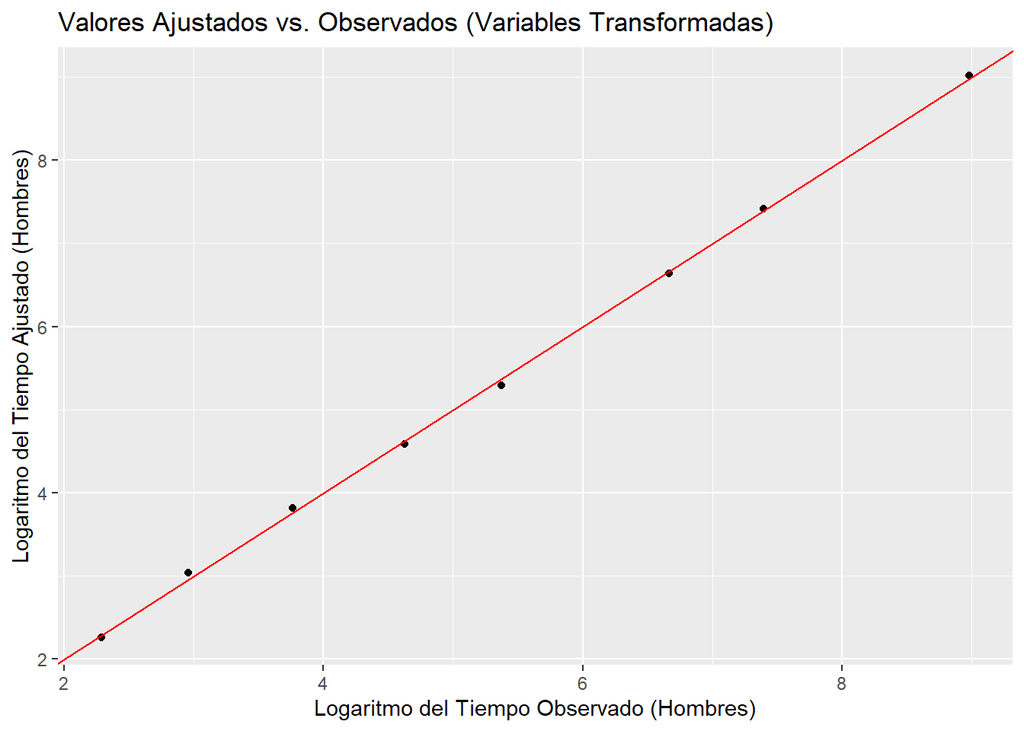

```r
ggplot(data = data.frame(observados = datos$log_tiempo_hombres, ajustados = fitted(modelo_log_hombres)),
       aes(x = observados, y = ajustados)) +
  geom_point() +
  geom_abline(intercept = 0, slope = 1, color = "red") +
  labs(x = "Logaritmo del Tiempo Observado (Hombres)", y = "Logaritmo del Tiempo Ajustado (Hombres)",
       title = "Valores Ajustados vs. Observados (Variables Transformadas)")
```

**(c) Repetir los dos apartados anteriores utilizando los datos de las mujeres.**

```r
modelo_mujeres <- lm(tiempo_mujeres ~ distancia, data = datos)
```

Resumen del modelo

```r
summary(modelo_mujeres)
```

```
##
## Call:
## lm(formula = tiempo_mujeres ~ distancia, data = datos)
##
## Residuals:
##     Min      1Q  Median      3Q     Max
## -150.29  -16.90   30.50   45.25   62.67
##
## Coefficients:
##               Estimate Std. Error t value Pr(>|t|)
## (Intercept) -72.579108  32.206936  -2.254   0.0651 .
## distancia     0.208450   0.002085  99.960 6.76e-11 ***
## ---
## Signif. codes:  0 '***' 0.001 '**' 0.01 '*' 0.05 '.' 0.1 ' ' 1
##
## Residual standard error: 79.55 on 6 degrees of freedom
## Multiple R-squared:  0.9994, Adjusted R-squared:  0.9993
## F-statistic:  9992 on 1 and 6 DF,  p-value: 6.756e-11
```

```r
library(ggplot2)
```

Gráfico de la dispersión y recta de la regresión

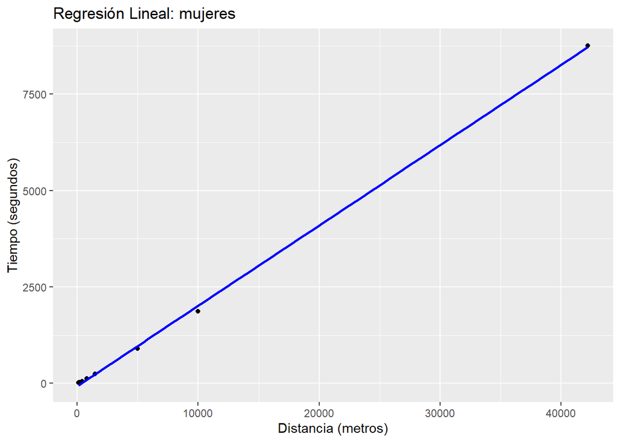

```r
ggplot(datos, aes(x = distancia, y = tiempo_mujeres)) +
  geom_point() +
  geom_smooth(method = "lm", se = FALSE, color = "blue") +
  labs(x = "Distancia (metros)", y = "Tiempo (segundos)",
       title = "Regresión Lineal: mujeres")
```

Obtener los residuos

```r
residuos_mujeres <- residuals(modelo_mujeres)
```

Gráfico de residuos

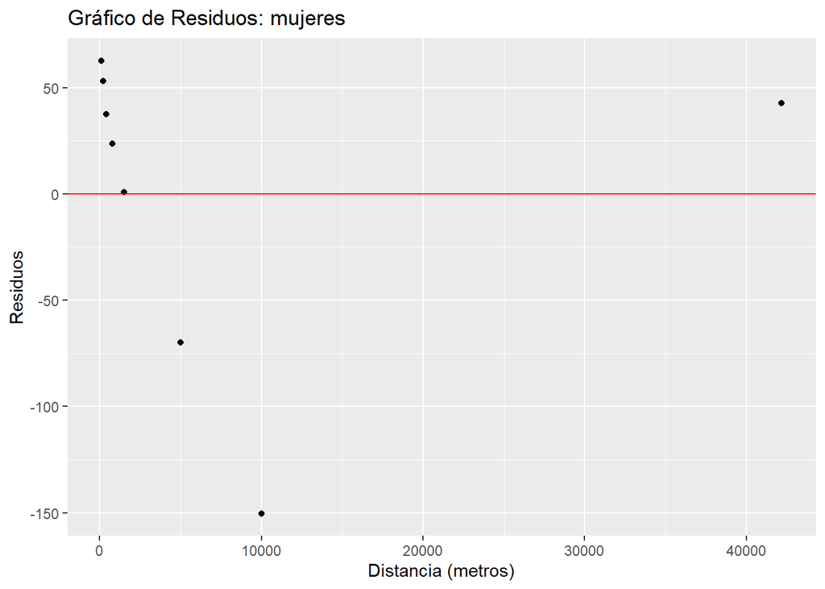

```r
ggplot(data = data.frame(distancia = datos$distancia, residuos = residuos_mujeres),
       aes(x = distancia, y = residuos)) +
  geom_point() +
  geom_hline(yintercept = 0, color = "red") +
  labs(x = "Distancia (metros)", y = "Residuos",
       title = "Gráfico de Residuos: mujeres")
```

Gráfico de valores ajustados vs. observados

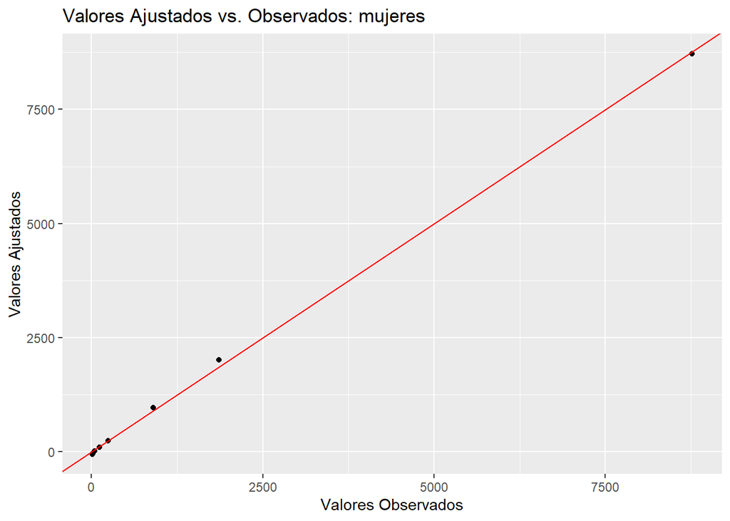

```r
ggplot(data = data.frame(observados = datos$tiempo_mujeres, ajustados = fitted(modelo_mujeres)),
       aes(x = observados, y = ajustados)) +
  geom_point() +
  geom_abline(intercept = 0, slope = 1, color = "red") +
  labs(x = "Valores Observados", y = "Valores Ajustados",
       title = "Valores Ajustados vs. Observados: mujeres")
```

Cálculo de la suma de cuadrados de los residuos y R²

Suma de cuadrados de los residuos

```r
suma_cuadrados_residuos <- sum(residuos_mujeres^2)
print(suma_cuadrados_residuos)
```

```
## [1] 37973.26
```

R-cuadrado

```r
r_cuadrado <- summary(modelo_mujeres)$r.squared
print(r_cuadrado)
```

```
## [1] 0.9993999
```

Transformar las variables a escala logarítmica

```r
datos$log_distancia <- log(datos$distancia)
datos$log_tiempo_mujeres <- log(datos$tiempo_mujeres)
```

Regresión lineal con las variables transformadas

```r
modelo_log_mujeres <- lm(log_tiempo_mujeres ~ log_distancia, data = datos)
```

Resumen del modelo

```r
summary(modelo_log_mujeres)
```

```
##
## Call:
## lm(formula = log_tiempo_mujeres ~ log_distancia, data = datos)
##
## Residuals:
##       Min        1Q    Median        3Q       Max
## -0.063794 -0.058885  0.002453  0.049190  0.072736
##
## Coefficients:
##               Estimate Std. Error t value Pr(>|t|)
## (Intercept)   -2.75908    0.08390  -32.88 5.26e-08 ***
## log_distancia  1.11721    0.01114  100.33 6.61e-11 ***
## ---
## Signif. codes:  0 '***' 0.001 '**' 0.01 '*' 0.05 '.' 0.1 ' ' 1
##
## Residual standard error: 0.0607 on 6 degrees of freedom
## Multiple R-squared:  0.9994, Adjusted R-squared:  0.9993
## F-statistic: 1.007e+04 on 1 and 6 DF,  p-value: 6.609e-11
```

Gráfico de dispersión y recta de regresión con las variables transformadas

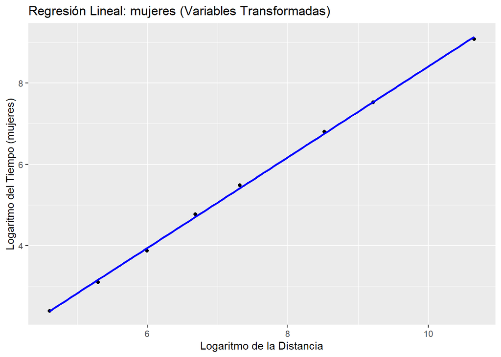

```r
ggplot(datos, aes(x = log_distancia, y = log_tiempo_mujeres)) +
  geom_point() +
  geom_smooth(method = "lm", se = FALSE, color = "blue") +
  labs(x = "Logaritmo de la Distancia", y = "Logaritmo del Tiempo (mujeres)",
       title = "Regresión Lineal: mujeres (Variables Transformadas)")
```

Gráfico de residuos vs. logaritmo de la distancia

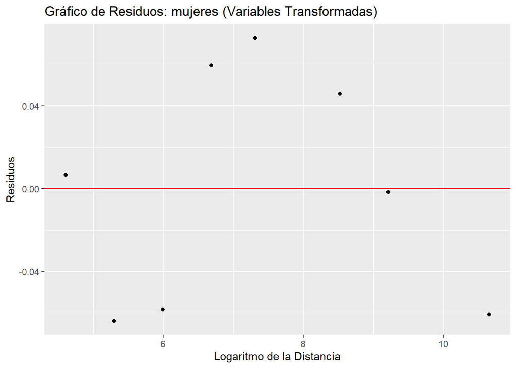

```r
residuos_log_mujeres <- residuals(modelo_log_mujeres)

ggplot(data = data.frame(log_distancia = datos$log_distancia, residuos = residuos_log_mujeres),
       aes(x = log_distancia, y = residuos)) +
  geom_point() +
  geom_hline(yintercept = 0, color = "red") +
  labs(x = "Logaritmo de la Distancia", y = "Residuos",
       title = "Gráfico de Residuos: mujeres (Variables Transformadas)")
```

Gráfico de valores ajustados vs. observados (en escala logarítmica)

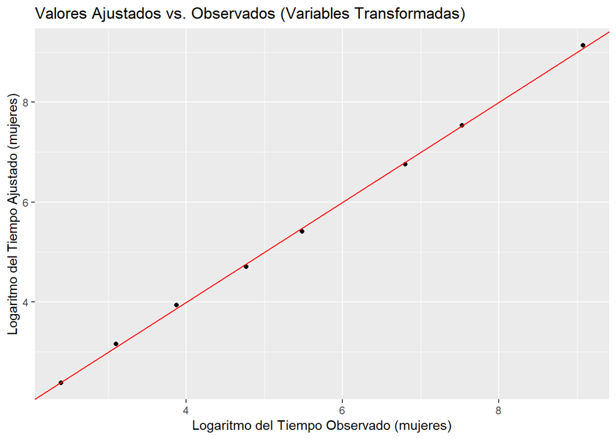

```r
ggplot(data = data.frame(observados = datos$log_tiempo_mujeres, ajustados = fitted(modelo_log_mujeres)),
       aes(x = observados, y = ajustados)) +
  geom_point() +
  geom_abline(intercept = 0, slope = 1, color = "red") +
  labs(x = "Logaritmo del Tiempo Observado (mujeres)", y = "Logaritmo del Tiempo Ajustado (mujeres)",
       title = "Valores Ajustados vs. Observados (Variables Transformadas)")
```